# Practical ML Project

Karim.bnm

6 mai 2016

## Introduction

Using devices such as Jawbone Up, Nike FuelBand, and Fitbit it is now possible to collect a large amount of data about personal activity relatively inexpensively. These type of devices are part of the quantified self movement - a group of enthusiasts who take measurements about themselves regularly to improve their health, to find patterns in their behavior, or because they are tech geeks. One thing that people regularly do is quantify how much of a particular activity they do, but they rarely quantify how well they do it. In this project, your goal will be to use data from accelerometers on the belt, forearm, arm, and dumbell of 6 participants. They were asked to perform barbell lifts correctly and incorrectly in 5 different ways. More information is available from the website here: http://groupware.les.inf.puc-rio.br/har (see the section on the Weight Lifting Exercise Dataset).

## Set up and data retrieval

```r
library(caret)
library(Hmisc)
```

```r
library(corrplot)
library(caTools)
library(nnet)
library(kernlab)
library(knitr)

trainurl <- "https://d396qusza40orc.cloudfront.net/predmachlearn/pml-training.csv"
testurl <- "https://d396qusza40orc.cloudfront.net/predmachlearn/pml-testing.csv"

download.file(trainurl, "pml-training.csv")
download.file(testurl, "pml-testing.csv")

training <- read.csv(file = "pml-training.csv", header=TRUE, sep=",", na.strings=c("NA","#DIV/0!",""))
testing <- read.csv(file = "pml-testing.csv", header=TRUE, sep=",", na.strings=c("NA","#DIV/0!",""))

#testing for name consistency between the training and testing sets.

all.equal(colnames(testing)[1:length(colnames(testing))-1], colnames(training)[1:length(colnames(training))-1])
```

```
## [1] TRUE
```

```r
#eliminating variables with very low variance

nearzero <- nearZeroVar(training, saveMetrics = TRUE)
training <- training[, !nearzero$nzv]

#eliminating variables with high rate of NAs

highNAs <- sapply(colnames(training),
            function(x)
                if(sum(is.na(training[, x])) > 0.6*nrow(training))
                    {
                    return(TRUE)
                    }
                    else
                    {
                    return(FALSE)
                    }
                 )

training <- training[, !highNAs]

#eliminating variables with low information value

training <- training[, -(1:6)]

#checking for dimension reduction (correlation between variables)

Hcorr <- findCorrelation(abs(cor(training[, -53])), cutoff=0.8)
names(training)[Hcorr]
```

```
##  [1] "accel_belt_z"     "roll_belt"        "accel_belt_y"
##  [4] "accel_dumbbell_z" "accel_belt_x"     "pitch_belt"
##  [7] "accel_arm_x"      "accel_dumbbell_x" "magnet_arm_y"
## [10] "gyros_forearm_y"  "gyros_dumbbell_x" "gyros_dumbbell_z"
## [13] "gyros_arm_x"
```

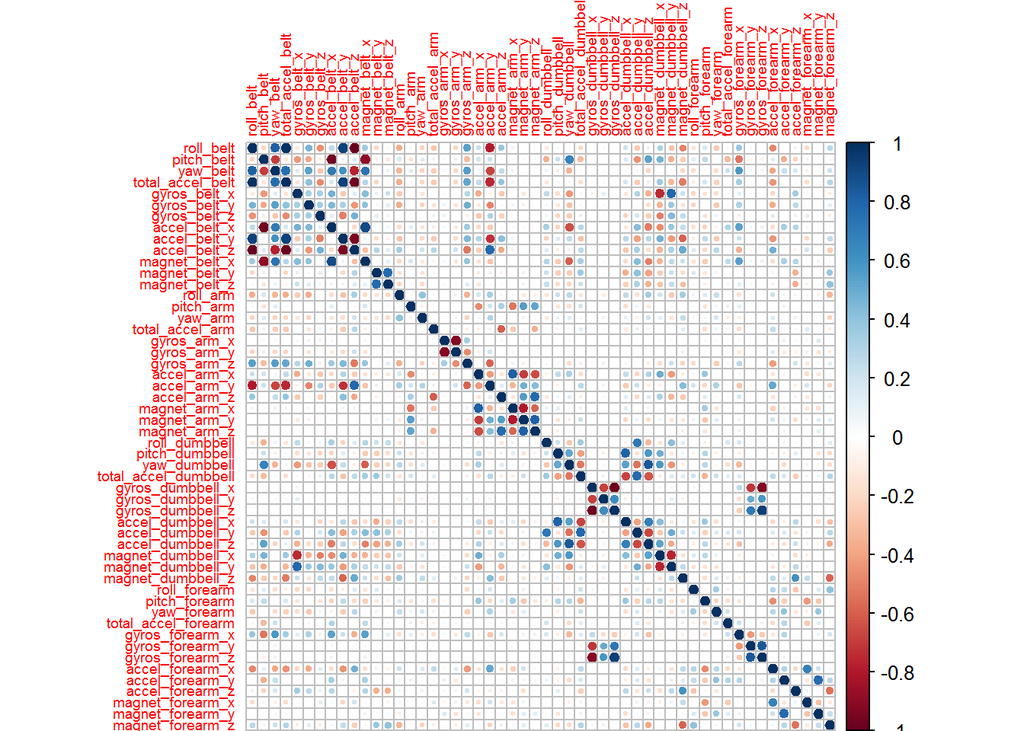

```r
# Visualization of the correlation matrix
corrplot(cor(training[,-53]), method = "circle", tl.cex=0.6)
```

```r
# Remaining variables after cleaning

names(training)
```

```
##  [1] "roll_belt"            "pitch_belt"           "yaw_belt"
##  [4] "total_accel_belt"     "gyros_belt_x"         "gyros_belt_y"
##  [7] "gyros_belt_z"         "accel_belt_x"         "accel_belt_y"
## [10] "accel_belt_z"         "magnet_belt_x"        "magnet_belt_y"
## [13] "magnet_belt_z"        "roll_arm"             "pitch_arm"
## [16] "yaw_arm"              "total_accel_arm"      "gyros_arm_x"
## [19] "gyros_arm_y"          "gyros_arm_z"          "accel_arm_x"
## [22] "accel_arm_y"          "accel_arm_z"          "magnet_arm_x"
## [25] "magnet_arm_y"         "magnet_arm_z"         "roll_dumbbell"
## [28] "pitch_dumbbell"       "yaw_dumbbell"         "total_accel_dumbbell"
## [31] "gyros_dumbbell_x"     "gyros_dumbbell_y"     "gyros_dumbbell_z"
## [34] "accel_dumbbell_x"     "accel_dumbbell_y"     "accel_dumbbell_z"
## [37] "magnet_dumbbell_x"    "magnet_dumbbell_y"    "magnet_dumbbell_z"
## [40] "roll_forearm"         "pitch_forearm"        "yaw_forearm"
## [43] "total_accel_forearm"  "gyros_forearm_x"      "gyros_forearm_y"
## [46] "gyros_forearm_z"      "accel_forearm_x"      "accel_forearm_y"
## [49] "accel_forearm_z"      "magnet_forearm_x"     "magnet_forearm_y"
## [52] "magnet_forearm_z"     "classe"
```

```r
# creation of a validation set

set.seed(1234)
train <- createDataPartition(training$classe, p = 0.7, list = FALSE)
train_set <- training[train,]
valid_set <- training[-train,]
```

## Model selection

```r
# Train control using pca (for dimension reduction) and 10 fold cross validation

tc <- trainControl(method = "cv", number = 10, verboseIter=FALSE , preProcOptions="pca", allowParallel=TRUE)

# fitting with logistic regression

lr <- train(classe~., data = train_set, trControl = tc, method = "LogitBoost")

#fitting with random forest

rf <- train(classe~., data=train_set, trControl=tc, method="rf")

# fitting with support vector machine (linear)

svm1 <- train(classe~., data=train_set, trControl = tc, method = "svmLinear")

# fitting with support vector machine (radial)

svm2 <- train(classe~., data=train_set, trControl = tc, method = "svmRadial")

# fitting with neural nets

nn <- train(classe~., data=train_set, trControl=tc, method="nnet", verbose=F)

# Compared results

Accuracy <- c(max(lr$results$Accuracy), max(rf$results$Accuracy), max(svm1$results$Accuracy), max(svm2$results$Accuracy), max(nn$results$Accuracy))

Kappa <- c(max(lr$results$Kappa), max(rf$results$Kappa), max(svm1$results$Kappa), max(svm2$results$Kappa), max(nn$results$Kappa))

model <- c("Logit", "Random Forest", "Linear SVM", "Radial SVM", "1 Layer Neural Net")

comparison <- cbind(model, Accuracy, Kappa)

kable(comparison)
```

[output not shown]

## Predictions on validation set and test set

```r
# predictions on the validation set using the RF model

predrf <- predict(rf, valid_set)
# Confusion matrix

conf_matrix <- confusionMatrix(valid_set$classe, predrf)

conf_matrix$overall
```

```
##       Accuracy          Kappa  AccuracyLower  AccuracyUpper   AccuracyNull
##      0.9943925      0.9929059      0.9921340      0.9961370      0.2861512
## AccuracyPValue  McnemarPValue
##      0.0000000            NaN
```

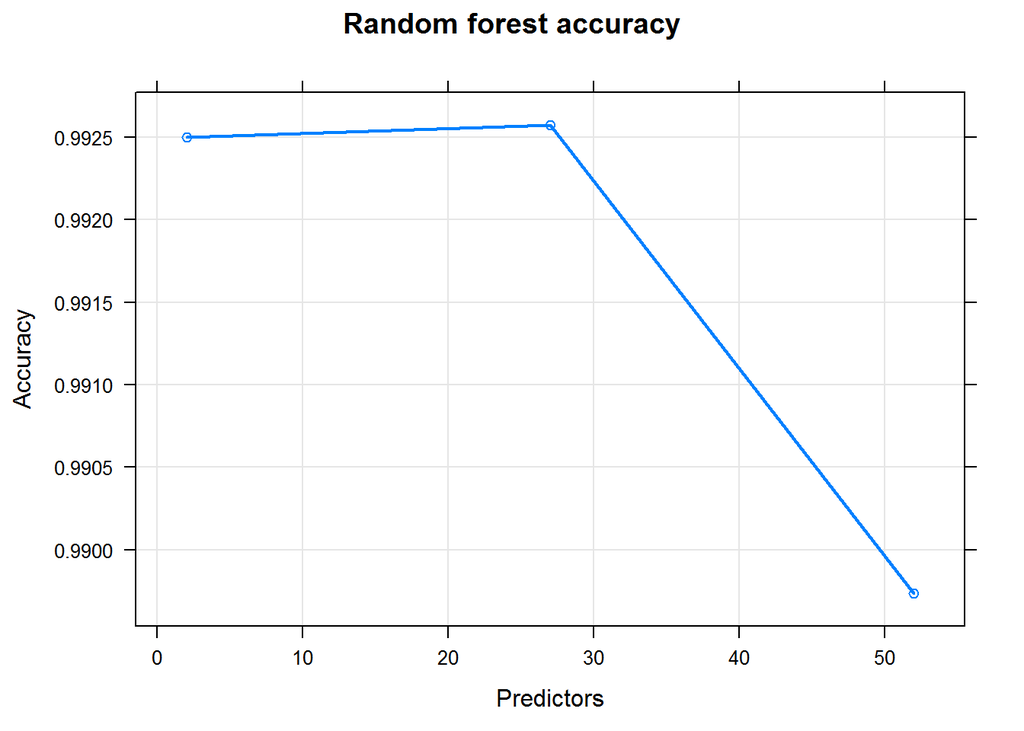

```r
# plot the random forest model

plot(rf, lwd = 2, main = "Random forest accuracy", xlab = "Predictors", ylab = "Accuracy")
```

```r
# final results

predrf_testing <- predict(rf, testing)

predrf_testing
```

```
##  [1] B A B A A E D B A A B C B A E E A B B B
## Levels: A B C D E
```

```r
# true accuracy of the predicted model
valid_set_accuracy <- sum(predrf == valid_set$classe)/length(valid_set$classe)

# out of sample error and percentage of out of sample error
outOfSampleError <- 1 - valid_set_accuracy
outOfSampleError*100
```

```
## [1] 0.5607477
```